# 52414 - lab 1 Solutions

Yohan Gross and Shoham Azulay

10/4/2022

# *Lab 1: Basic Data Wrangling and Plotting, Distributions*

### Submission Instructions

This lab will be submitted in pairs using GitHub (if you don’t have a pair, please contact us).  
Please follow the steps in the [GitHub-Classroom Lab 1](https://classroom.github.com/a/4PpjneTd) to create your group’s Lab 1 repository.  
**Important: your team’s name must be `FamilyName1_Name1_and_FamilyName2_Name2`**.  
You can collaborate with your partner using the `git` environment; You can either make commits straight to the main repository, or create individual branches (recommended). However, once done, be sure to merge your branches to master - you will be graded using the most recent master version - your last push and merge before the deadline of May 15th.  
**Please do not open/review other peoples’ repositories - we will be notified by GitHub if you do.**

Your final push should include this Rmd file (with your answers filled-in), together with the html file that is outputted automatically by knitr when you knit the Rmd. Anything else will be disregarded. In addition, please adhere to the following file format:  
`Lab_1_FamilyName1_Name1_and_FamilyName2_Name2.Rmd/html`

## Analysis of the World Covid-19 Dataset

The `world-of-data` website hosts world-wide epidemiological data on the Corona Virus (COVID-19). The dataset is compiled by the Johns Hopkins University Center for Systems Science and Engineering (JHU CCSE) from various sources, and follows The dataset contains data since January 2020. For the data and more information about it, please visit [here](https://github.com/owid/covid-19-data/tree/master/public/data).

You can see several nice visualizations of the data [here](https://ourworldindata.org/covid-vaccinations)

we will focus on analyzing the Covid-19 cases, deaths and vaccinations data over time for different countries and continents.

### General Guidance

- Your solution should be submitted as a full Rmd report integrating text, code, figures and tables. For each question, describe first in the text of your solution what you’re trying to do, then include the relevant code, then the results (e.g. figures/tables) and then a textual description of them.
- In most questions the extraction/manipulation of relevant parts of the data-frame can be performed using commands from the `tidyverse` and `dplyr` R packages, such as `head`, `arrange`, `aggregate`, `group-by`, `filter`, `select`, `summaries`, `mutate`, `order` etc.
- When displaying tables, show the relevant columns and rows with meaningful names, and describe the results.
- When displaying figures, make sure that the figure is clear to the reader, axis ranges are appropriate, labels for the axis , title and different curves/bars are displayed clearly (font sizes are large enough), a legend is shown when needed etc. Explain and describe in text what is shown in the figure.
- In many cases, data are missing (e.g. `NA`). Make sure that all your calculations (e.g. taking the maximum, average, correlation etc.) take this into account. Specifically, the calculations should ignore the missing values to allow us to compute the desired results for the rest of the values (for example, using the option `na.rm = TRUE`).
- Grading: There are $10$ questions overall. Each question is worth $10$ points for the lab grade. The questions vary in length and difficulty level. It is recommended to start with the simpler and shorter questions.

### Questions:

1. **Loading data and basic processing:**
   1. Load the complete covid19 dataset in `csv` format from [world-of-data](https://github.com/owid/covid-19-data/tree/master/public/data) into a data-frame in `R`.  
      Change if needed the class of the `date` variable to `Date` and check that the class is correct.
   2. List in a table the top five *dates* in terms of number of `new_cases` for `High income` countries. Show only the date and the number of new cases at this date.  
      Repeat the same with two additional separate tables for top five dates for `new_deaths` and `new_vaccinations`.
2. **Comparing low vs. high income countries:**
   1. Write a function that receives as input the data-frame, and a column name as string. The function plots the value of the input column as a function of the date for both `High income` and `Low income` countries, shown on the same graph with different colors or symbols. Use meaningful axis and plot labels, and add an informative legend. `NA` or other no-number values should not be displayed.
   2. Use the function written in (a.) and plot of the number of `new_cases_per_million` vs. date for the high vs. low income countries. Next, make a similar plot for the *log* of the *smoothed* number of new cases per million, `new_cases_smoothed_per_million`. Which plot is easier to interpret? explain.  
      Similarly, make two additional separate plots for the *log* of the *smoothed* number of new deaths and new vaccinations per million as a function of date for the high vs. low income countries. Describe the plotted results.
3. **Storing and analyzing current (cumulative) values:**
   1. Create a new data-frame called `current` with *one row per country* (and other locations), that for each country will store as columns the country name (`location`) and `continent`, and also the **current** values (latest date reported for each value) for: `total_cases_per_million`, `total_deaths_per_million`, `total_vaccinations_per_hundred`, `people_fully_vaccinated_per_hundred`, `total_boosters_per_hundred` and `excess_mortality_cumulative_per_million`.
   2. Show the values for the current `total_deaths_per_million` in different countries in a histogram with 30 bins. Does this histogram look close to the normal distribution? Compute the *skewness* and *kurtosis* for this distribution, and explain what they mean about the empirical distribution of the data.
   3. Next, make a scatter plot showing the current `total_deaths_per_million` (y-axis) vs. the current `total_cases_per_million`. Compute a linear regression line of the total number of deaths per million as a function of the total number of cases per million and add the fitted regression line to the plot. What is the slope and what does it represent?
4. **Vaccinations in different continents:**
   1. For each of the six different continents (`Africa`, `Asia`, `Europe`, `North America`, `Oceania`, `South America`), make a boxplot of the distribution of the (current) total number of vaccinations per hundred in all the countries in the continent. Show one figure with the six boxplots next to each other. (Use the new `current` data-frame created in qu. 3). Find two outlier countries (can be of any continent) and write their name and value.
   2. Define (for the original data-frame from qu. 1) a new column called `booster_ratio`, that lists for each date the fraction of individuals that got a third, booster shot in a country (`total_boosters`), out of all individuals that got two shots (`people_fully_vaccinated`), by dividing the two columns (if either of them is `NA` or if the denominator is zero, set `booster_ratio` to `NA`). Plot the `booster_ratio` as a function of time for the six continents (on the same plot, using different colors) and describe the results.
5. **Displaying monthly data:**
   1. For each month from January 2020 until March 2022 compute the total number of new cases per million in this month for each country individually (around 230 numbers for each month), and make a boxplot representing the empirical distribution fo these ~230 values. Show the boxplots for all months in one plot together in a chronological order, from left to right.

      *Guidance:* (i) Beware to not double-count cases/deaths/vaccinations. (ii) Treat each month separately (e.g. March 2020 and March 2022 are different).
   2. Repeat (a.), but this time with the total number of `new_deaths` and `new_vaccinations` for each month (two separate plots).

      What can you conclude about the pandemic at different periods from these plots? describe the results for each of the three plots in 2-3 sentences.
6. **R - disease reproduction number:** Add to the covid data-frame a new column called `R_cases`, defined for `location` and `date` as the number of `new_cases_smoothed` at this date, divided by the value of the same variable seven days before (if the value seven days before is zero or not defined, define `R_cases` at the current date to be `NA`). This column represents roughly the expected number of people that each case infects, and determines the spread of the disease, with values above (below) one indicating that the disease is spreading (declining).

   Plot the `R_cases` value as a function of time for `Israel`, `United Kingdom` and `United States`, and describe the results.  
   List in a table the number of days at which the disease was spreading (value above 1) in each of the three countries.
7. **Displaying data on the world map:** Use the `rworldmap` package to display the world map and color each country based on the `total_deaths_per_million`. Repeat for `total_vaccinations_per_hundred`, and `excess_mortality_cumulative_per_million`. Describe the resulting maps in a couple of sentences.

   List the top three countries for each of these variables in a table.

   **Guidance:** Use the `joinCountryData2Map` and `mapCountryData` commands to make the plots. Keep countries with missing data in white.
8. **Cross correlations and delay from diagnosis to death:** We want to use the data and *cross-correlation* in order to study the typical *time delay* between *diagnosis* of Covid-19 and *death* from Covid-19 for cases not surviving the disease. For two functions of time $X(t)$ and $Y(t)$ (here $t$ is discrete, representing for example days) we define their *cross-correlation* at time-delay $\Delta_t$ as follows: $cross_{corr}(\Delta_t ; X, Y) = Corr(X(t), Y(t+\Delta_t))$.  
   That is, the cross-correlation function at the time-delay $\Delta_t$ for two vectors of length $n$ is obtained by computing the Pearson correlation coefficient of the vector $X[1,...,n-\Delta_t]$ with the vector $Y[\Delta_t+1,...,n]$, for $\Delta_t>0$. For $\Delta_t < 0$ we replace the role of $X$ and $Y$ in this formula.
   1. Write a function that receives as input the data-frame, a country name and the name of two columns, and computes the value of their cross-correlation in this country for time delay of up to two months apart, that is for all values of $\Delta_t$ between $-60$ days and $60$ days. The function should return a vector of length $121$ representing these correlations. *Do not* use available cross-correlation functions in $R$, but write the function yourself.
   2. Use the function from (a.) to compute the cross correlation between the number of `new_cases_smoothed` and `new_deaths_smoothed` for the entire *World*, and plot it as a function of $\Delta_t$. At what time delay is the cross correlation maximized? what is your interpretation of this time-delay?
9. **Death risk after Covid-19 infection:**
   1. Add to the main covid data-frame a new column called `death_rate`, defined for each `location` and `date` as the number of `total_deaths` divided by the number of `total_cases`. This column represents the risk of a person diagnosed with covid to die from the disease. Plot for each of the six continents and the entire world the `death_rate` as a function of time (one plot with separate colors/symbols). Since there is a delay from time of diagnosis to time of death, the initial values of this column are less reliable as a measure of death risk, hence start your plot on *January 1st, 2021*. Do we see a decrease in the risk over time? can you suggest explanations for the observed trends?
   2. Make a similar plot for all continents and the world, but for the `total_vaccinations_per_hundred` variable. Do the plots suggest that the change in risk is correlated to the change in the number of vaccinations?
10. **Excess mortality:** It is claimed that in some countries the death-rate from Covid-19 is under-reported. We can investigate this using excess mortality data - this data lists the number of deaths from all causes at each country, compared to the usual number of deaths at the same country and date calculated from previous years mortality data. The gap between the two, representing and increase (or decrease) in deaths beyond the usual rate, is called ‘excess mortality’, and might be partially or fully explained by deaths from Covid-19.
    1. Use the `current` data-frame to make a scatter plot of the current date `total_deaths_per_million` vs. the `excess_mortality_cumulative_per_million` for all countries for which excess mortality data is available. Add the lines $y=x, y=x+2000$ and $y=x-2000$ to the plot. Mark on the graph in a different color all the countries for which the difference between the the excess mortality and the covid death rate (per million) is at least 2000 and add their names to the plot (you can use the `text` function).
    2. Pick three countries where the excess mortality was at least 2000 per million *above* the covid death rate, and that have at least $50$ available data points for each for `excess_mortality_cumulative_per_million`. Use the main covid data-frame to plot as a function of time both the `total_deaths_per_million` and the `excess_mortality_cumulative_per_million` for each country (one plot - use different colors/symbols). Identify from the plot for each country the time periods where most deaths not explained by Covid-19 occurred.

**Solution:**

1. Loading data and basic processing:
1. Loading the data

```r
df <- read.csv(file = 'C:/Users/yohan/Downloads/owid-covid-data.csv')
df$date <- as.Date(df$date)

# Modifying date from character to Date format. This will be easier to work with
colnames(df)[which(names(df) == 'date')] <- 'Date'
```

2. Listing five top dates for “new_cases”, “new_deaths” and “new_vaccinations” for high income country

```r
high <- filter(df,location == 'High income')
for (x in c("new_cases", "new_deaths","new_vaccinations")){
  print(high %>% select(Date, .data[[x]])%>%top_n(n = 5) %>% arrange(desc(.data[[x]])))
}
```

```
##         Date new_cases
## 1 2022-01-19   2830533
## 2 2022-01-18   2737804
## 3 2022-01-10   2589365
## 4 2022-01-21   2558959
## 5 2022-01-26   2532201
```

```
##         Date new_deaths
## 1 2021-01-20      11047
## 2 2021-01-26      10279
## 3 2021-01-12      10170
## 4 2021-01-27      10079
## 5 2021-01-08       9967
```

```
##         Date new_vaccinations
## 1 2021-08-04         11980640
## 2 2021-12-17          9748265
## 3 2021-06-10          9537907
## 4 2021-06-11          9504648
## 5 2021-06-09          9452118
```

2. High vs. Low income
1. Writing a function to compare high vs low income country on an arbitrary variable

```r
highvlow <- function(data, col) {
  ggplot(filter(data,location %in% c('High income', 'Low income')), aes(x=Date, y=.data[[col]], color=location)) + geom_line() + labs(title = paste0("Date vs ", col),y=col)
}
```

2. plotting high vs low income country according to several variable and their logarithmic version

```r
df[['log_new_cases_smoothed_per_million']] <- log(df$new_cases_smoothed_per_million)
df[['log_new_deaths_smoothed_per_million']] <- log(df$new_cases_smoothed_per_million)
df[['log_new_vaccinations_smoothed_per_million']] <- log(df$new_cases_smoothed_per_million)
for (x in c('new_cases_smoothed_per_million','log_new_cases_smoothed_per_million','new_deaths_smoothed_per_million','log_new_deaths_smoothed_per_million','new_vaccinations_smoothed_per_million','log_new_vaccinations_smoothed_per_million')) {
  print(highvlow(df, x))
}
```

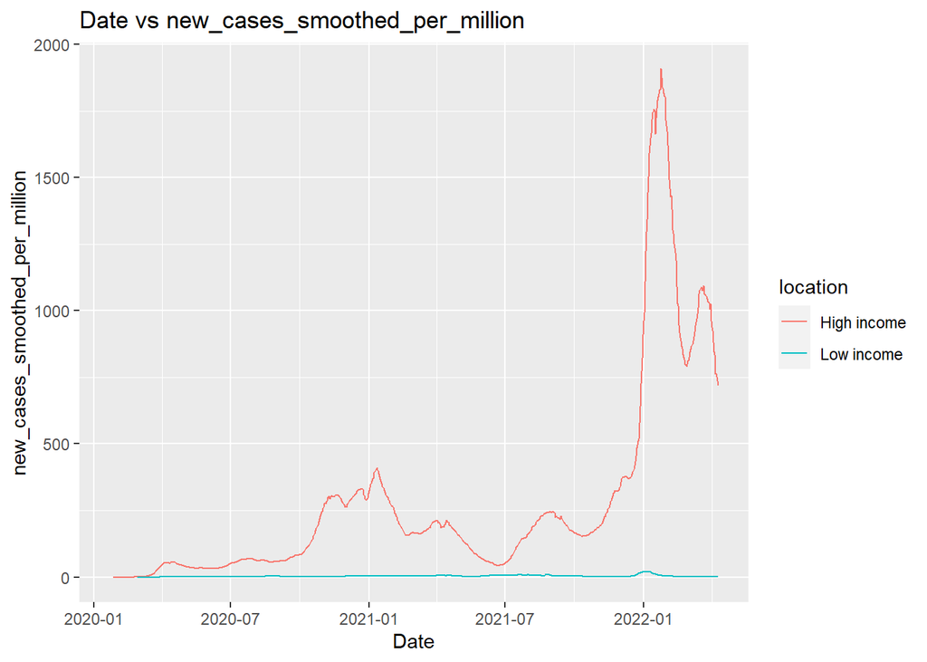

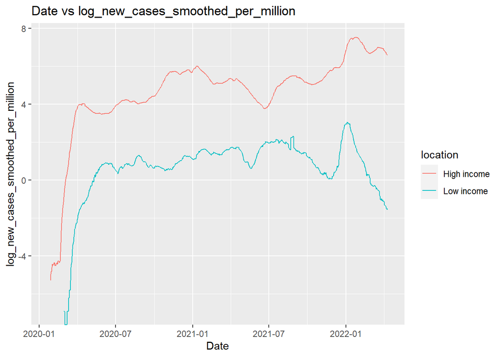

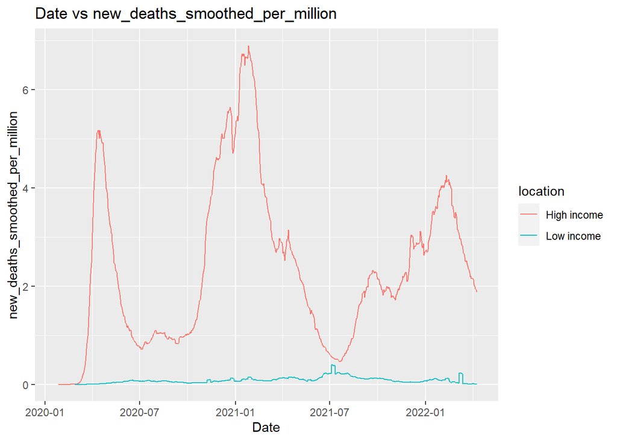

[figure not shown]

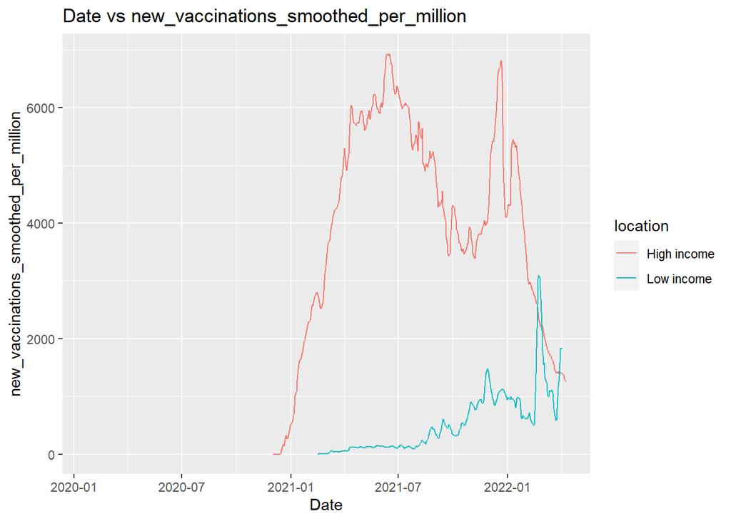

[figure not shown]

Surprisingly, we can clearly assert from the plots that the high income countries suffered from a genuinely harder epidemic than the low income ones. This result is counter-intuitive and might be caused by some flaw in the data. Let’s control for population size and for number of data points.

```r
cases <- "new_cases_smoothed_per_million"
deaths <- "new_deaths_smoothed_per_million"
vacc <- "new_vaccinations_smoothed_per_million"

df %>% filter(location == "Low income" |location == "High income") %>%  group_by(location) %>%  summarise(num_new_cases_smoothed_per_million=sum(!is.na(.data[[cases]])),num_new_deaths_smoothed_per_million=sum(!is.na(.data[[deaths]])), new_vaccinations_smoothed_per_million=sum(!is.na(.data[[vacc]])))
```

```
## # A tibble: 2 x 4
##   location    num_new_cases_smoothed_per_mill~ num_new_deaths_~ new_vaccination~
##   <chr>                                  <int>            <int>            <int>
## 1 High income                              805              805              495
## 2 Low income                               773              773              414
```

```r
df %>% filter(location == "Low income" |location == "High income") %>% group_by(location) %>% summarise(mean_pop = mean(population))
```

```
## # A tibble: 2 x 2
##   location      mean_pop
##   <chr>            <dbl>
## 1 High income 1214930230
## 2 Low income   665149040
```

3. Last day of data set analysis

```r
current <- df %>% group_by(location) %>% fill(everything(),.direction="down") %>% filter(Date == max(Date) & continent != "" ) %>% select(continent, location,total_cases_per_million, total_deaths_per_million,
total_vaccinations_per_hundred, people_fully_vaccinated_per_hundred, total_boosters_per_hundred ,excess_mortality_cumulative_per_million)
```

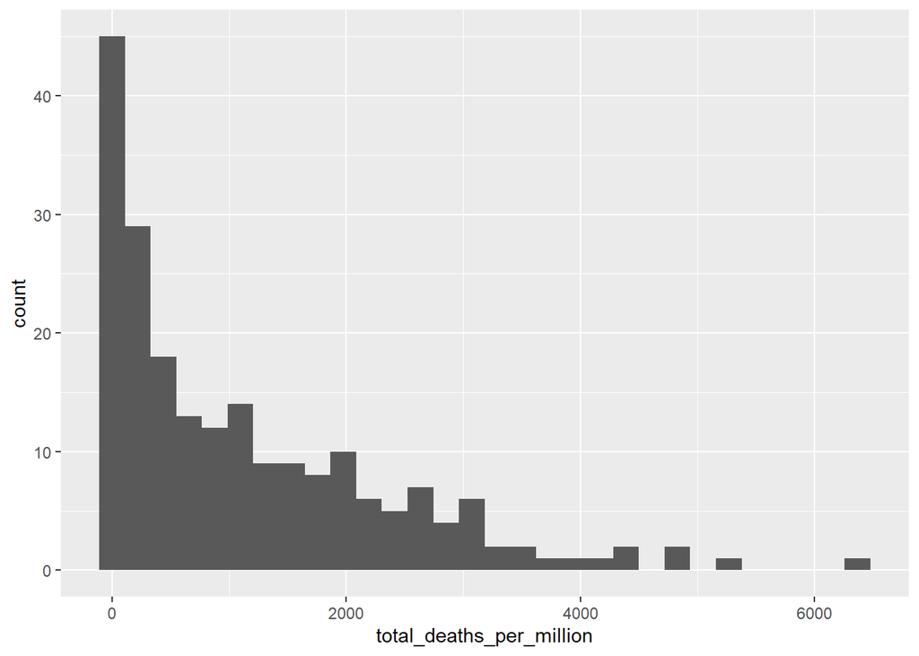

```r
ggplot(current, aes(total_deaths_per_million)) + geom_histogram(bins = 30)
```

As we can see in this plot the distribution of the deaths per million looks absolutely not like a normal distribution as it is right-tailed asymmetric.

```r
skewness(current$total_deaths_per_million,na.rm = TRUE)
```

```
## [1] 1.348668
```

as expected from the histogram, the skewness of the distribution is positive, meaning that his mean is higher than its median, which translate visually as a right-tailed asymmetric distribution

```r
kurtosis(current$total_deaths_per_million,na.rm = TRUE)
```

```
## [1] 1.743342
```

The kurtosis of the distribution is leptokurtic (>0) meaning that it has a tendency to produce more outliers and rare event than a normal distribution with the same variance. In other word it is a relatively fat-tailed distribution c.

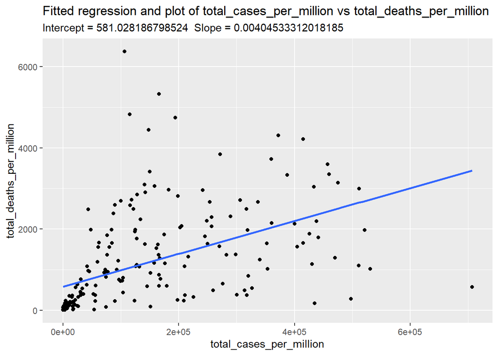

```r
lr <- lm(current$total_deaths_per_million~current$total_cases_per_million)$coefficient
ggplot(current, aes(x=total_cases_per_million, y=total_deaths_per_million))+geom_point()+geom_smooth(method = "lm",se=F)+labs(title = "Fitted regression and plot of total_cases_per_million vs total_deaths_per_million ",subtitle = paste0("Intercept = ", lr[1],"  Slope = ", lr[2]) )
```

As we see in the graph the slope is 0.004. We can interpret that by saying that if the linear model is accurate here then for each new case per million we get 0.004 deaths per million which is equivalent to say that approximately 0.4 % of infected people died from Covid 19 on this specific date.

4. Vaccination analysis

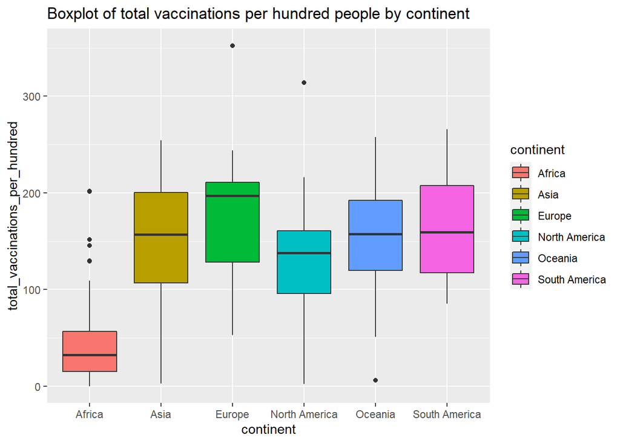

```r
ggplot(current, aes(continent, total_vaccinations_per_hundred,fill=continent)) + geom_boxplot() + labs(title="Boxplot of total vaccinations per hundred people by continent")
```

```r
ungroup(current)  %>% select(location, total_vaccinations_per_hundred) %>% top_n(n=2)
```

```
## # A tibble: 2 x 2
##   location  total_vaccinations_per_hundred
##   <chr>                              <dbl>
## 1 Cuba                                314.
## 2 Gibraltar                           352.
```

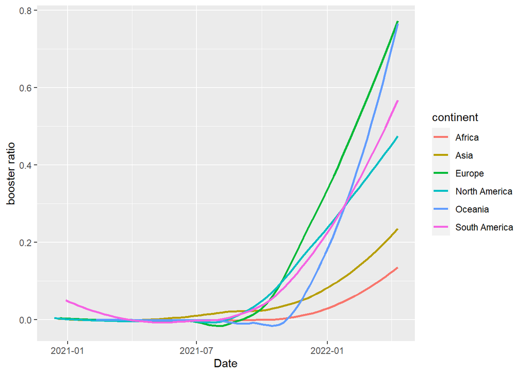

```r
df <- df %>% mutate(booster_ratio = total_boosters/people_fully_vaccinated)

df %>% filter(continent != "") %>% group_by(continent, Date) %>% summarise(tb=sum(total_boosters,na.rm=T),pv= sum(people_fully_vaccinated,na.rm=T) ) %>%  ggplot(aes(Date,tb/pv , color=continent)) + geom_smooth(se=F) + labs(y='booster ratio')
```

5. Using boxplot over time
1. Writing a function to boxplot the distribution (where each country is a data point) of a variable over time (monthly)

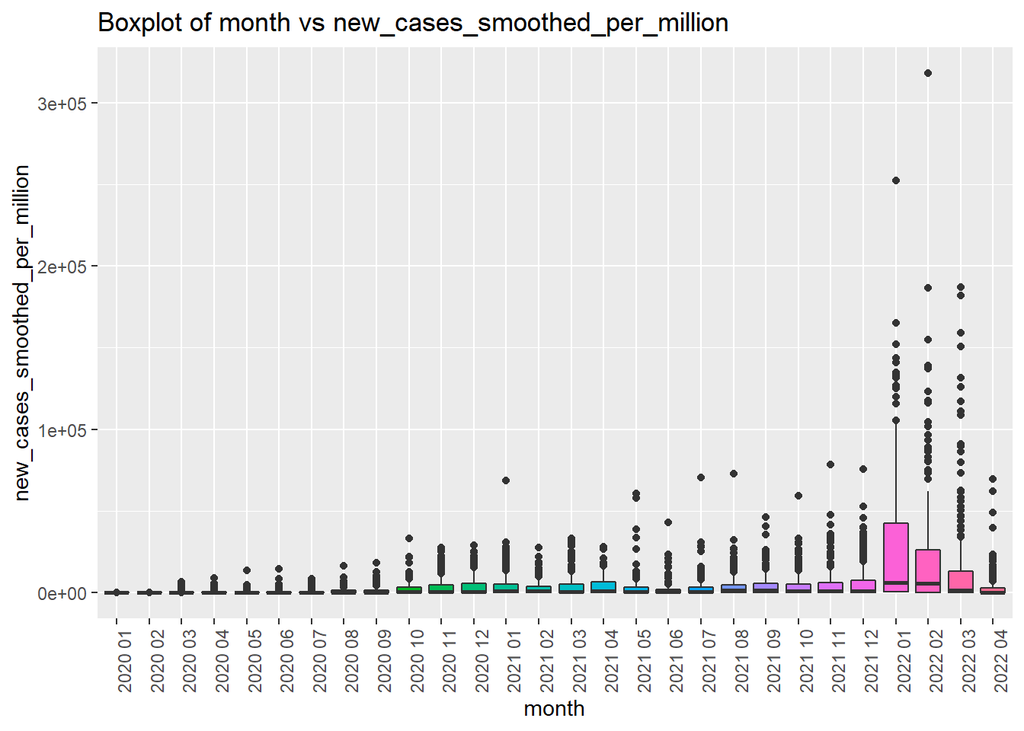

```r
bmplot<-function(x) {
df %>% filter(continent != "") %>% mutate(month = format(Date, format="%Y %m")) %>%  group_by(location,month) %>% summarise(x= sum(.data[[x]], na.rm=TRUE)) %>%
ggplot(aes(month,x, fill=month))+ geom_boxplot() + labs(title=paste0("Boxplot of month vs ", x),y = x) + theme(axis.text.x = element_text(angle = 90),legend.position = "none")
}
bmplot("new_cases_smoothed_per_million")
```

We can see several waves of new cases across time in the plot, with a general increasing tendency. Debut 2022 is special in the sense that the distribution of new cases became more dispersed, and with far more outliers, which fits with the spread of the highly contagious Omicron.

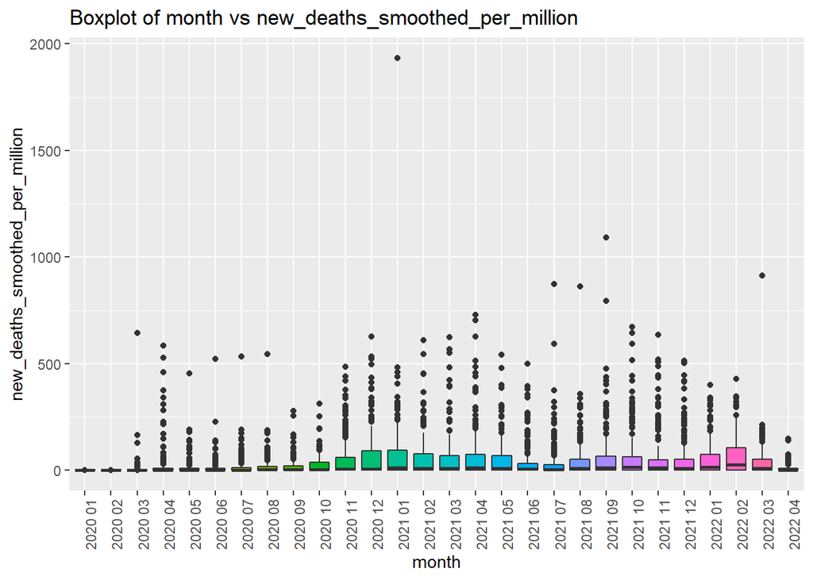

```r
bmplot("new_deaths_smoothed_per_million")
```

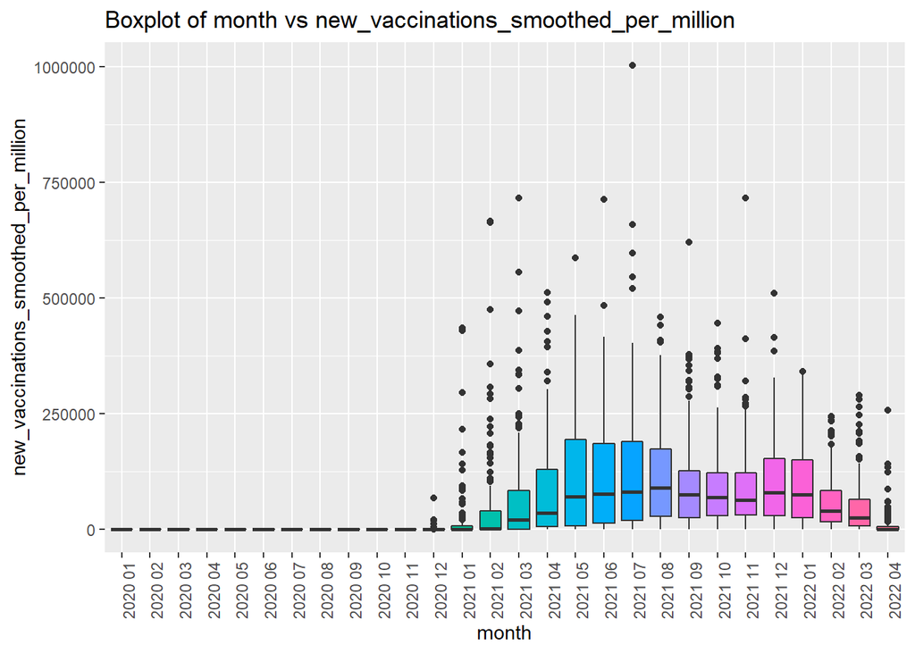

```r
bmplot("new_vaccinations_smoothed_per_million")
```

In the total deaths plot, we can also see at least 3 waves of deaths with a tendency of rising variability over time. The waves seems to be correlated to the number of cases waves.

In the new vaccinations per million, the distributions suddenly rises extremely fast with big variability after debut 2021 and slowly decay to the last month of the data set. This can be interpreted as a display of the fact that vaccines spread really fast and pretty inequally across the world the moment they were out until now.

6. Defining and ploting R (reproduction number)

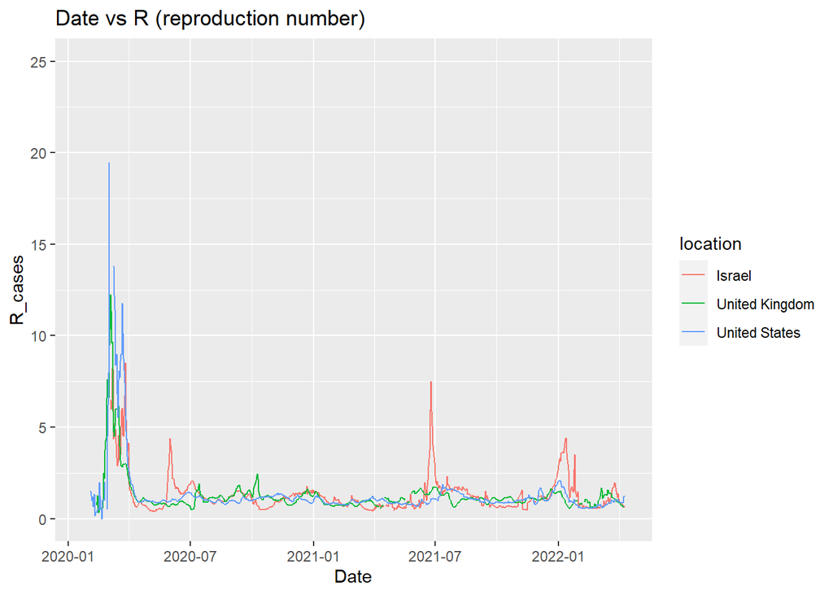

```r
df <- df %>% group_by(location) %>% mutate(shifted= shift(new_cases_smoothed, 7))
df <- df %>% mutate(R_cases = new_cases_smoothed/shifted)
df$R_cases[is.nan(df$R_cases) | is.infinite(df$R_cases)] <- NA
countries <- c('Israel', 'United Kingdom', 'United States')
df %>% filter(location %in% countries) %>% select(Date, R_cases) %>% group_by(location) %>% ggplot(aes(Date,R_cases, color=location)) + geom_line() + labs(title="Date vs R (reproduction number)") + ylim(0,25)
```

```r
df %>% filter(location %in% countries & R_cases >= 1) %>% select(location,R_cases) %>% group_by(location) %>% summarise(number_of_spreading_days=n())
```

```
## # A tibble: 3 x 2
##   location       number_of_spreading_days
##   <chr>                             <int>
## 1 Israel                              400
## 2 United Kingdom                      444
## 3 United States                       398
```

The plot shows that back in 2020 the 3 country shared simultaneously the same tendencies. But, as time passed by, the epidemic cycle in US and UK was pretty much the same whereas in Israel, the Reproduction number seems to be able to peak significantly higher than in the two other countries. This might be the result of similar policies enforced in UK and US, that are different from the ones in Israel.

7. Mapping the data

```r
# Solution code in R
data2map <- joinCountryData2Map(current,
                                joinCode = "NAME",
                                nameJoinColumn = "location")
```

```
## 218 codes from your data successfully matched countries in the map
## 11 codes from your data failed to match with a country code in the map
## 25 codes from the map weren't represented in your data
```

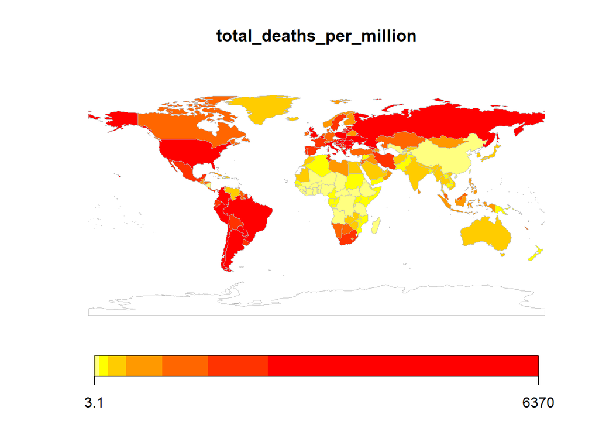

```r
mapCountryData( data2map, nameColumnToPlot="total_deaths_per_million")
```

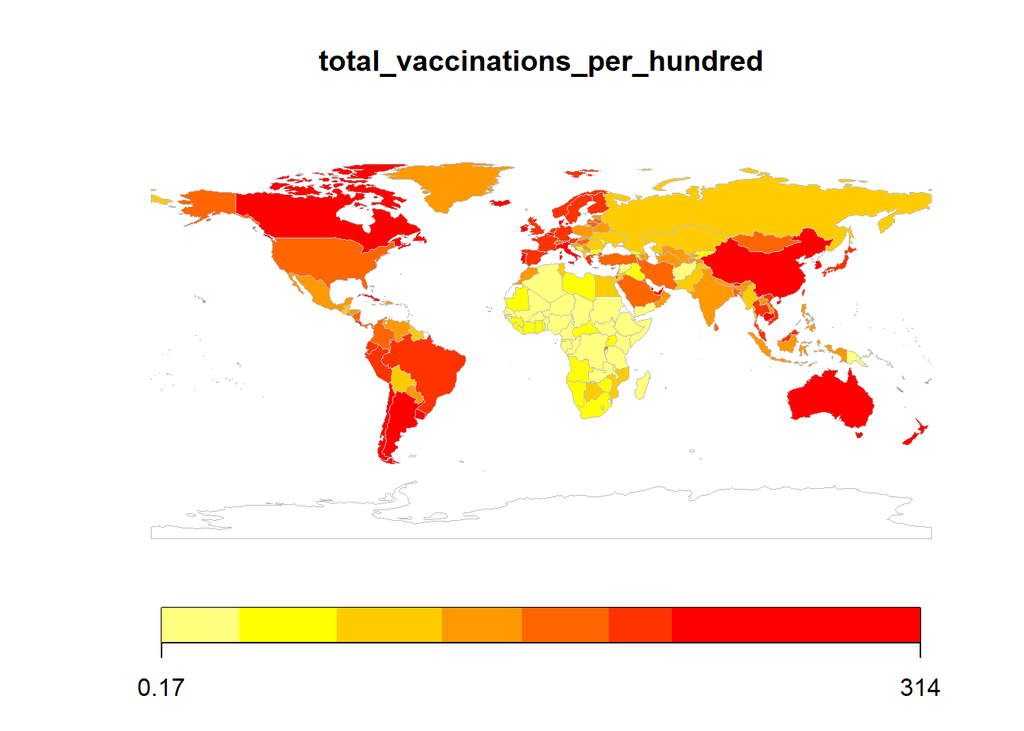

```r
mapCountryData( data2map, nameColumnToPlot="total_vaccinations_per_hundred")
```

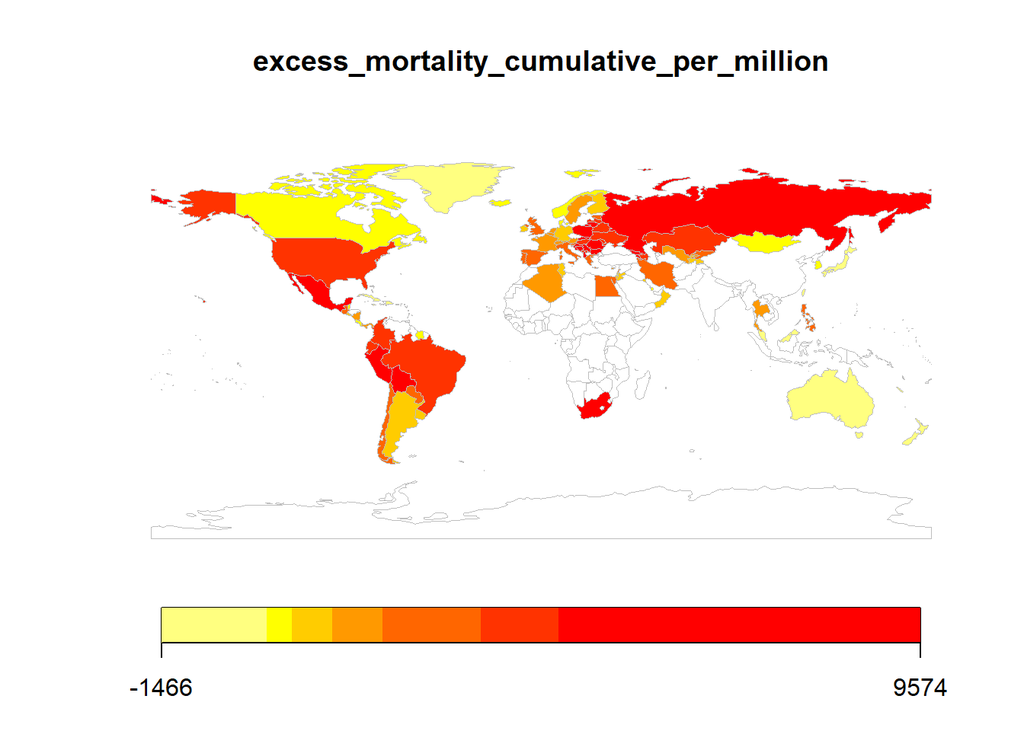

```r
mapCountryData( data2map, nameColumnToPlot="excess_mortality_cumulative_per_million")
```

```r
cat <- c("total_deaths_per_million","total_vaccinations_per_hundred", "excess_mortality_cumulative_per_million")

for (x in cat) {
  print(ungroup(current)  %>% select(location,.data[[x]]) %>% top_n(3) %>% arrange(desc(.data[[x]])))
}
```

```
## # A tibble: 3 x 2
##   location               total_deaths_per_million
##   <chr>                                     <dbl>
## 1 Peru                                      6370.
## 2 Bulgaria                                  5321.
## 3 Bosnia and Herzegovina                    4821.
```

```
## # A tibble: 3 x 2
##   location  total_vaccinations_per_hundred
##   <chr>                              <dbl>
## 1 Gibraltar                           352.
## 2 Cuba                                314.
## 3 Chile                               266.
```

```
## # A tibble: 3 x 2
##   location excess_mortality_cumulative_per_million
##   <chr>                                      <dbl>
## 1 Bulgaria                                   9574.
## 2 Serbia                                     8159.
## 3 Russia                                     7975.
```

8. Cross-correlation analysis

```r
crosscorr <- function(data,loc, col1, col2) {
  dc <- data %>% filter(location == loc) %>% select(col1=col1,col2=col2)
  cross_vec <- rep(NA, 121)
  for(i in -60:60){
    temp <- dc %>% mutate(shift_col2 = shift(col2,i))
    cross_vec[61 + i] <- cor(temp$col1, temp$shift_col2, use = "complete.obs")
    }
  cross_vec
}
```

```r
world <- crosscorr(df,"World", "new_cases_smoothed", "new_deaths_smoothed")
```

[output not shown]

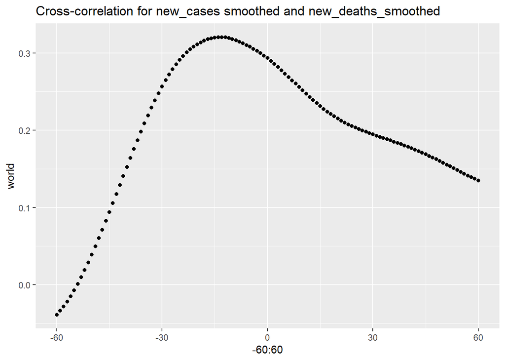

```r
ggplot(as.data.frame(world), aes(-60:60, world))+ geom_point() +labs(title="Cross-correlation for new_cases smoothed and new_deaths_smoothed")
```

9.Death rate and vaccine analysis

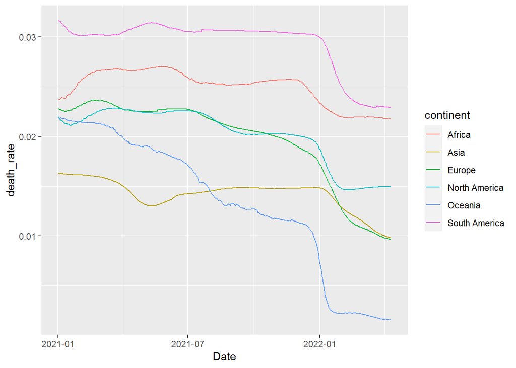

```r
df$death_rate <- df$total_deaths/df$total_cases
df %>%  filter(Date >= "2021-01-01" & continent != "") %>% group_by(continent,Date) %>% summarise(td=sum(total_deaths,na.rm=T),tc= sum(total_cases,na.rm=T) ) %>% ggplot(aes(Date, td/tc, color=continent)) + geom_line() + labs(y="death_rate")
```

The general tendency is that the death rate obviously is decreasing. This might be the result of anti-covid policies and the massive worldwide vaccination campaign.

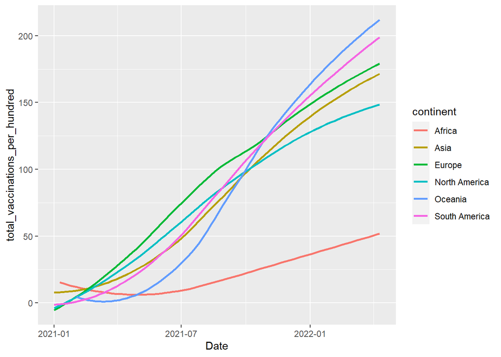

```r
df %>%  filter(Date >= "2021-01-01" & continent != "") %>% group_by(continent,Date) %>% summarise(total_vaccinations_per_hundred=mean(total_vaccinations_per_hundred,na.rm=T)) %>% ggplot(aes(Date, total_vaccinations_per_hundred, color=continent)) + geom_smooth(se=F)
```

The plots can suggest that the spread of vaccines is negatively correlated with deaths rates, but the correlation could be a cross correlated one with a lag of many months, as we observe that the biggest decreasing in death rates happend nearly a whole year after the begining of the worldwide vaccination campaign.

10. Excess of mortality analysis

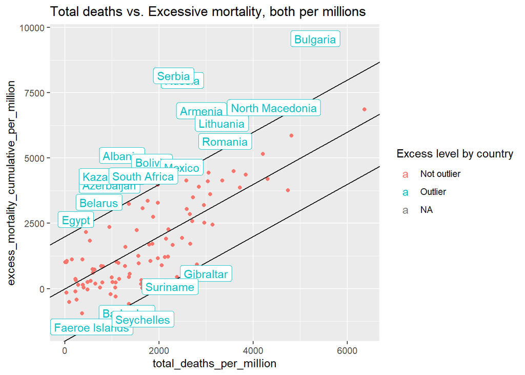

```r
current %>% mutate(outlier=ifelse(total_deaths_per_million< excess_mortality_cumulative_per_million+2000 & total_deaths_per_million > excess_mortality_cumulative_per_million-2000 ,"Not outlier","Outlier")) %>%

ggplot(aes(total_deaths_per_million, excess_mortality_cumulative_per_million)) + geom_point(aes(colour=outlier)) + geom_abline() +
geom_abline(slope=1, intercept = 2000) + geom_abline(slope=1, intercept = -2000)+
geom_label(aes(label=ifelse(outlier=="Outlier",location,NA),colour=outlier)) + scale_colour_discrete(name="Excess level by country") + labs(title="Total deaths vs. Excessive mortality, both per millions")
```

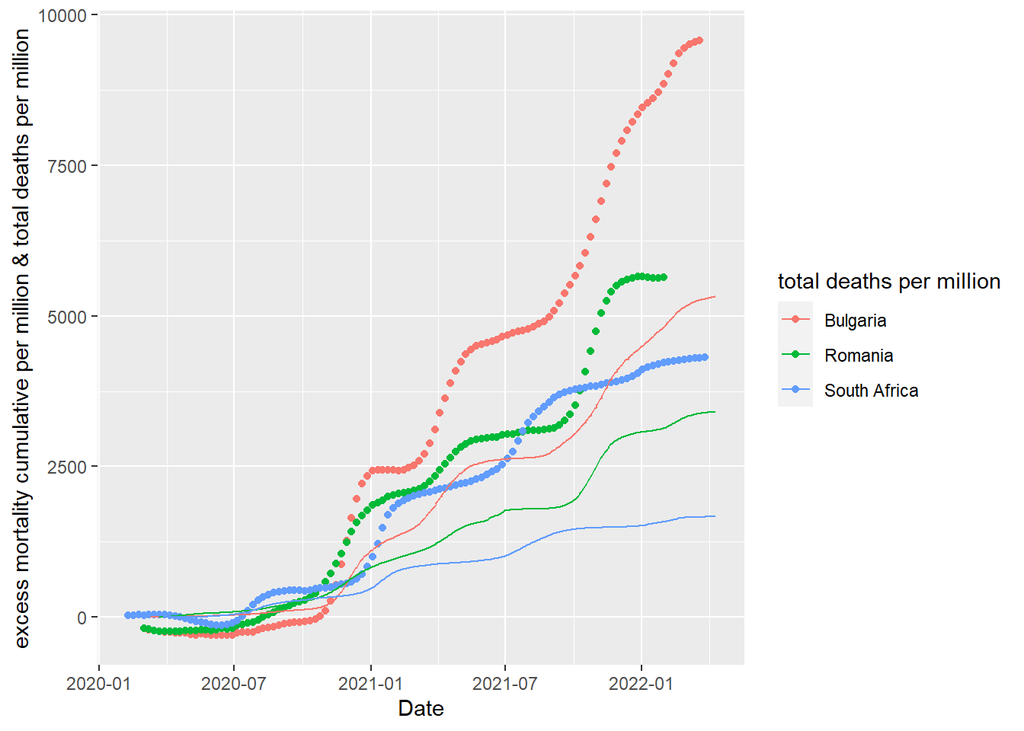

```r
outliers <- df %>% filter(location %in% c("Bulgaria", "South Africa","Romania") ) %>% select(location, Date,total_deaths_per_million, excess_mortality_cumulative_per_million)

ggplot() + geom_point(data=outliers, aes(Date, excess_mortality_cumulative_per_million, color=location)) + geom_line(data=outliers, aes(Date, total_deaths_per_million, color=location)) + labs(y="excess mortality cumulative per million & total deaths per million", colour="total deaths per million")
```